# HW 2 SDS 315

Somya Krishna - sk55256

2025-01-25

# Problem 1: Beauty or not, in the classroom

In this problem, we will dive into how UT Austin students view their professors.

## Part A

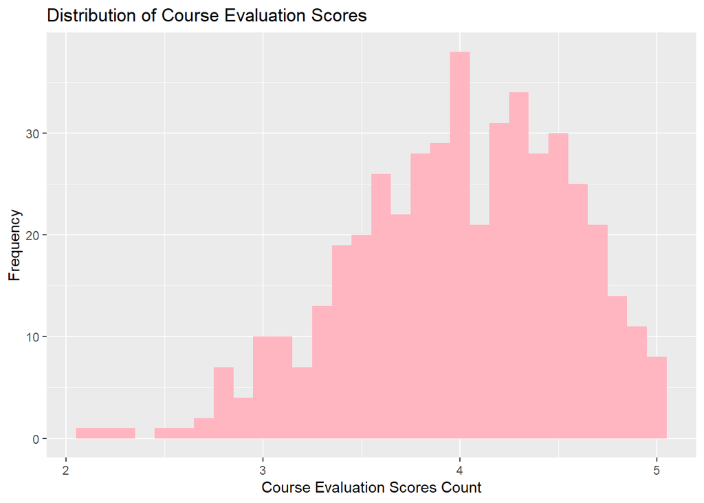

This histogram describes the professor’s average teaching evaluation score, on a scale of 1 to 5, for courses in the sample. Most of the professors seem to be around the 4/5 rating, with very few ratings under 3/5.

## Part B

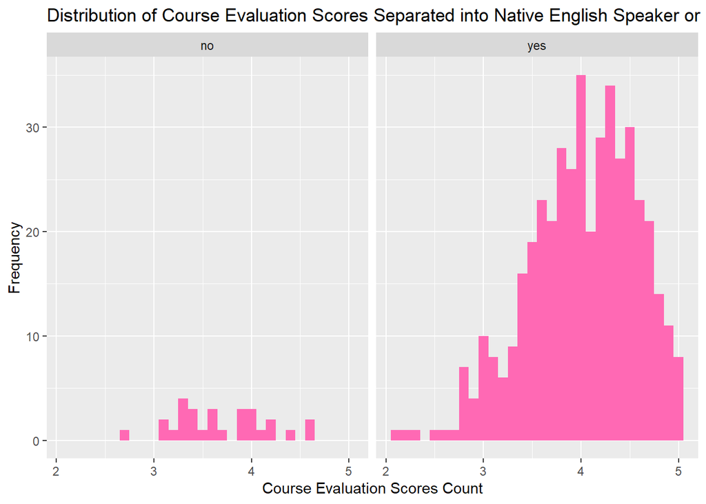

This histogram displays the same x-variable of average teaching evaluation scores as the last graph, except it divides the graph into two categories. On the left shows professors who are not native English speakers. On the right shows professors who are native English speakers. As seen from the histograms, most professors seem to be native English speakers, assuming that this is a sample that is fairly representative of the UT Austin professor population.

## Part C

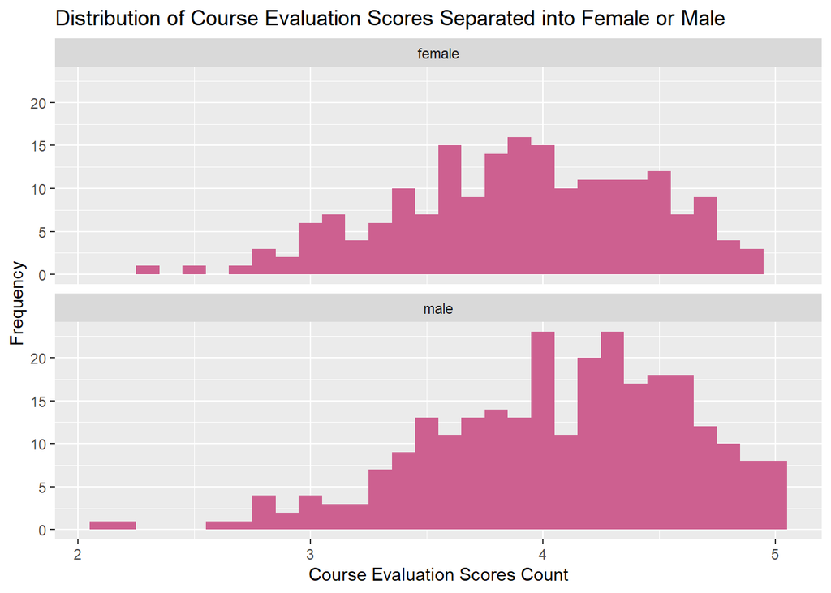

## Part D

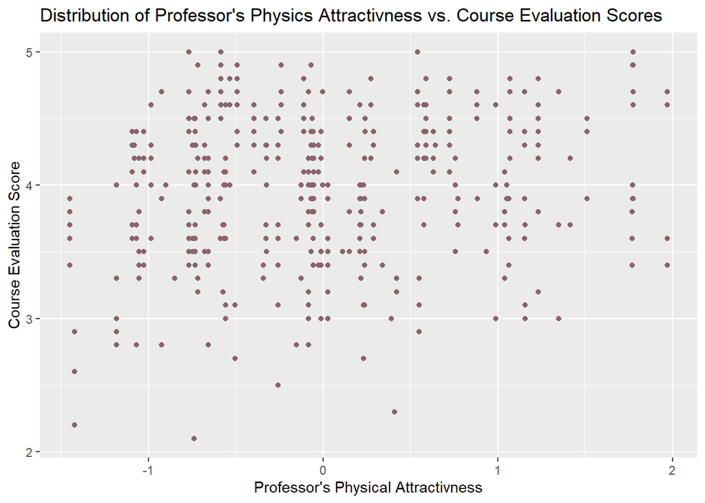

In the scatterplot above, we can see that there is little to no association between the course evaluation score and the professor’s physical attractiveness because there seems to be little to no apparent pattern in any direction.

# Problem 2: Bike Sharing

In this problem, we will observe the factors that affect bike rental counts.

## Plot A

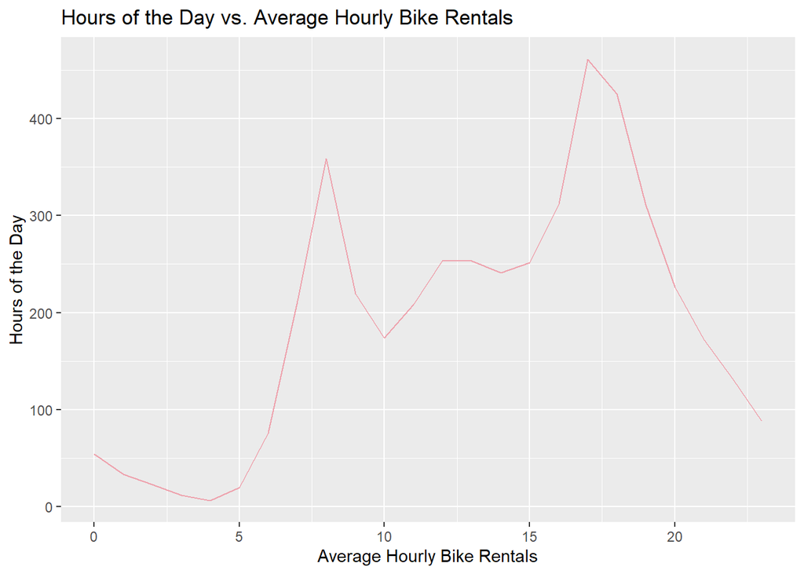

## Plot B

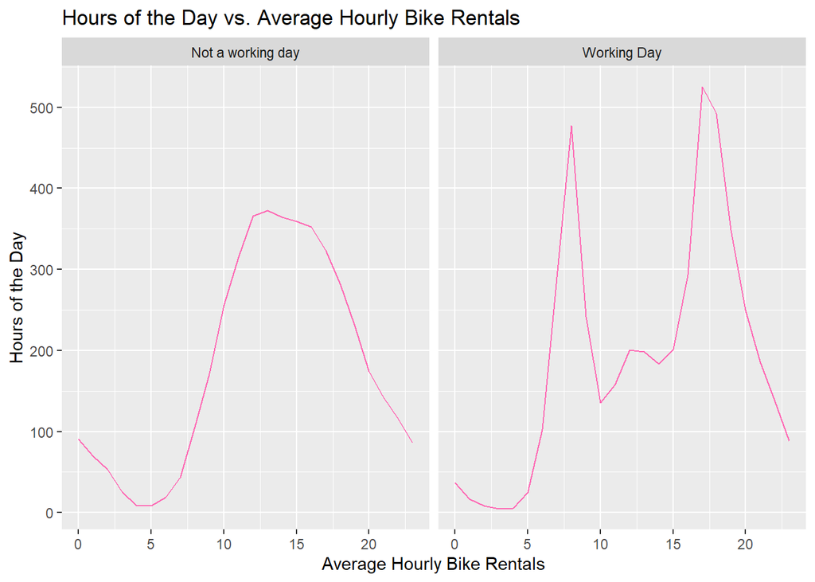

These line graphs show the average hourly bike rentals based on hours of the day, split into working days vs. non-working days. People seem to rent more bikes on working days. We can see this by noticing that the rentals are higher in the right graph which shows working days.

## Plot C

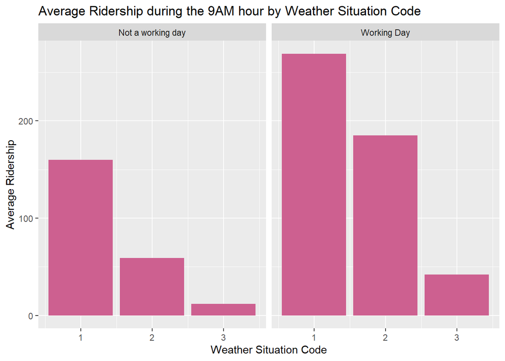

This barplot shows average ridership during the 9AM hour by weather situation code. These are the code meanings: – 1: Clear, Few clouds, Partly cloudy, Partly cloudy – 2: Mist + Cloudy, Mist + Broken clouds, Mist + Few clouds, Mist – 3: Light Snow, Light Rain + Thunderstorm + Scattered clouds, Light Rain + Scattered clouds – 4: Heavy Rain + Ice Pallets + Thunderstorm + Mist, Snow + Fog

Average ridership seems to be the most when it is a working day with clear to few clouds. It seems to be least when it is raining or snowing and not a working day. The weather seems to have a heavy impact on ridership because the more clouds and rain there are, the less that people rent bikes.

# Problem 3: Capital Metro UT Ridership

In this problem, we will dive into ridership of buses in the UT Austin area.

## Faceted Plot 1

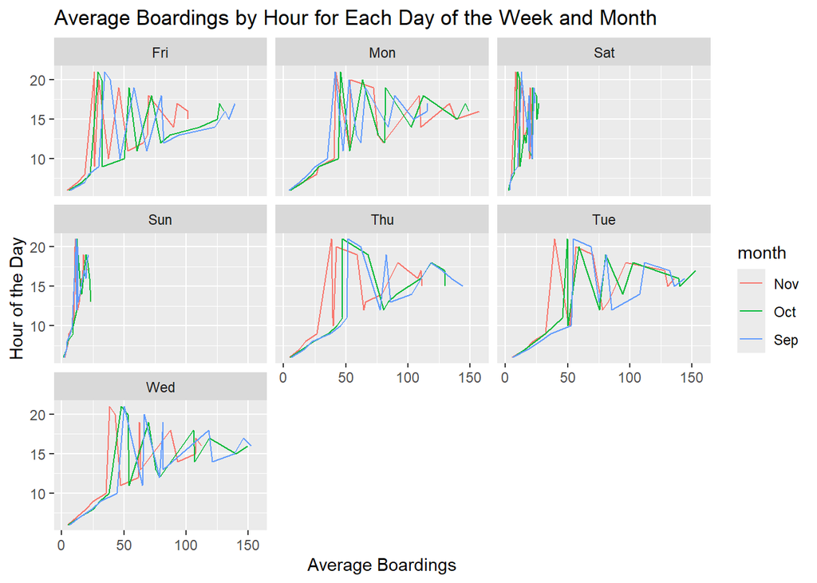

We can see here that weekdays have more boardings throughout the day, while weekends do not have boardings throughout the whole day. I believe this is because people use bikes more to get to work, to get lunch at work, then to come home. The boardings also seem to be pretty similar regardless of the month.

## Faceted Plot 2

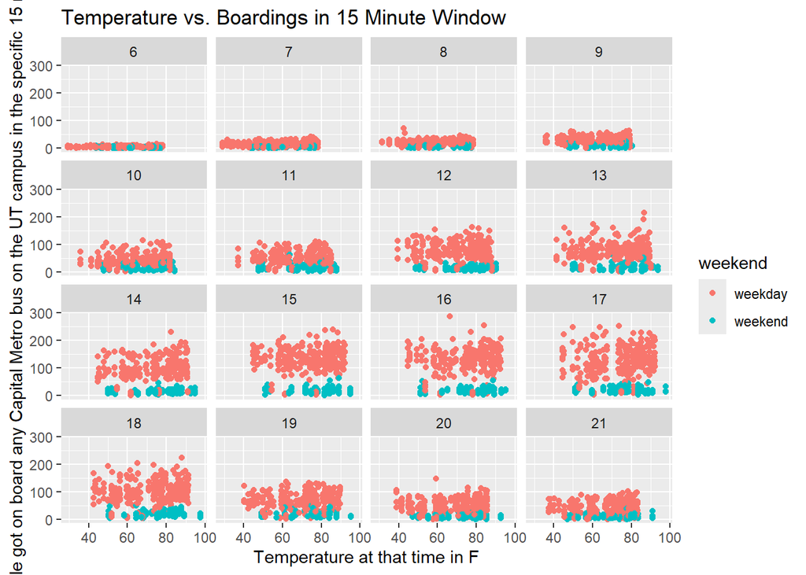

The number of boardings seems to be consistent across all temperatures, with a slight increase at higher temperatures. Weekdays have more boardings then weekends.

# Problem 4: Wrangling the Billboard Top 100

In this problem, we analyze songs that appeared on the weekly Billboard Top 100 chart since 1958.

## Part A

| performer | song | count |
| --- | --- | --- |
| Imagine Dragons | Radioactive | 87 |
| AWOLNATION | Sail | 79 |
| Jason Mraz | I'm Yours | 76 |
| The Weeknd | Blinding Lights | 76 |
| LeAnn Rimes | How Do I Live | 69 |
| LMFAO Featuring Lauren Bennett & GoonRock | Party Rock Anthem | 68 |
| OneRepublic | Counting Stars | 68 |
| Adele | Rolling In The Deep | 65 |
| Jewel | Foolish Games/You Were Meant For Me | 65 |
| Carrie Underwood | Before He Cheats | 64 |

Here, we can see the top 10 most popular songs since 1958.

## Part B

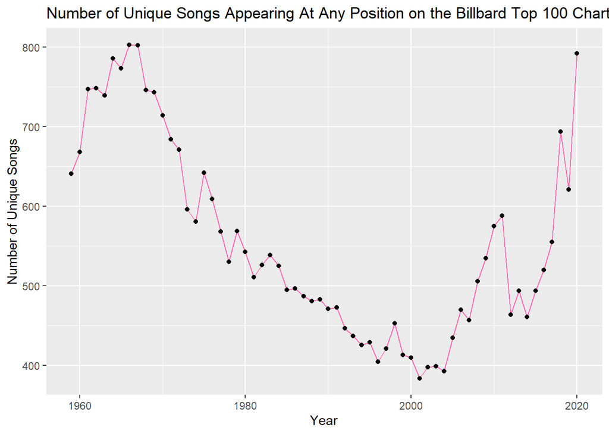

## Part C

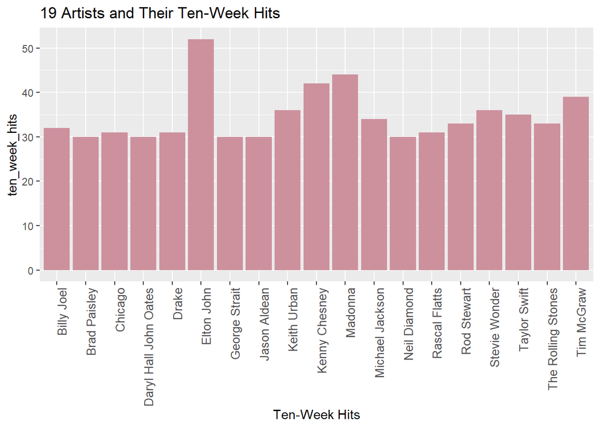

Most of the top 19 artists had around the same number of ten-week hits, but Elton John had significantly more than the rest of the artists.